# Индивидуальный проект

Второй этап

Кузнецова С. В.

Российский университет дружбы народов, Москва, Россия

16 марта 2023

# Информация

## Докладчик

- Кузнецова София Вадимовна
- 16.03.2023
- Студент направления прикладная информатика
- Российский университет дружбы народов

## Цель работы

Добавить к сайту данные о себе.

## Задание

Добавить к сайту данные о себе:

1.Список добавляемых данных. 2.Разместить фотографию владельца сайта. 3.Разместить краткое описание владельца сайта (Biography). 4.Добавить информацию об интересах (Interests). 5.Добавить информацию от образовании (Education). Сделать пост по прошедшей неделе. Добавить пост на тему по выбору: -Управление версиями. Git. -Непрерывная интеграция и непрерывное развертывание (CI/CD).

# Выполнение второго этапа индивидуального проекта

## Добавление фотографии на сайт

Для начала добавим нашу фотографию. Для этого мы должны проделать данный путь : “work”, “blog”, “content”, “authors”, “admin”. Здесь удаляем предыдущий avatar и добавляем свой.

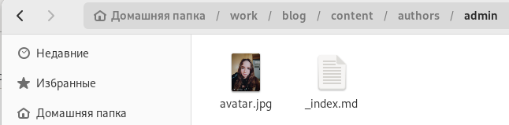

Добавление фотографии

## Добавление информации о себе

В этом каталоге (“admin”) открываем файл “_index.md”. В него мы внесём наше имя, фамилию. Также добавим биографию, интересы, образование и т.д.

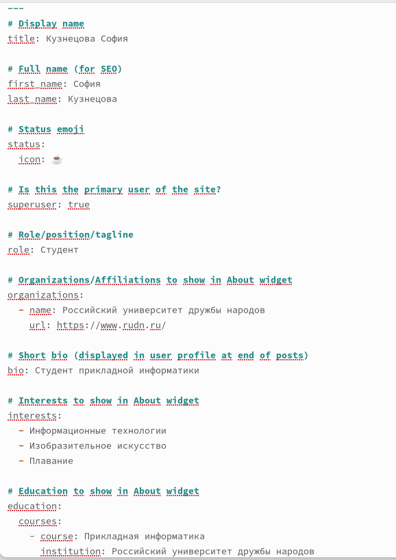

Добавление информации о себе

## Создание постов

Следующим шагом будет создание двух постов. Открываем терминал из каталога “blog” и вводим команду : hugo new -kind post post/(название поста).

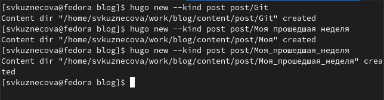

Создание двух постов

## Проверка создания постов

После этого в каталоге “post” появляются наши новые подкаталоги “GIT” и “Моя прошедшая неделя”. Именно внутри этих подкаталогов мы будем добавлять информацию для постов.

[figure not shown]

Новые подкаталог для постов

## Внесение информации для поста

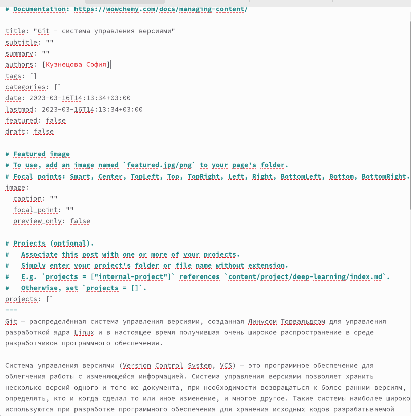

Информация для поста

## Внесение информации для поста

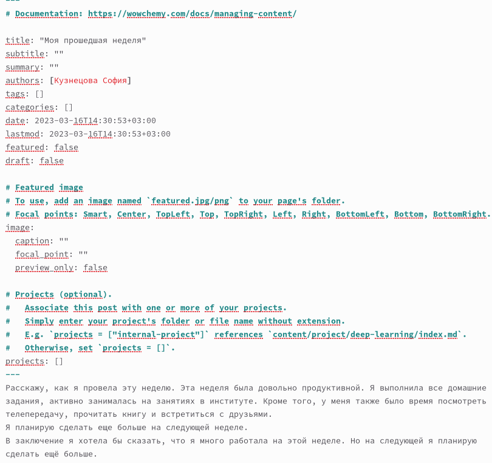

Информация для поста

## Запуск команды hugo

Чтобы вся наша информация выгрузилась на сайт, откроем в каталоге “blog” терминал и запустим команду hugo.

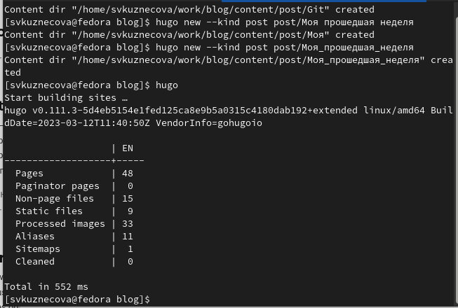

Запуск команды hugo

## Выгрузка на github

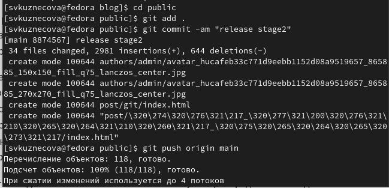

Выгрузка из подкаталога “public”

## Выгрузка на github

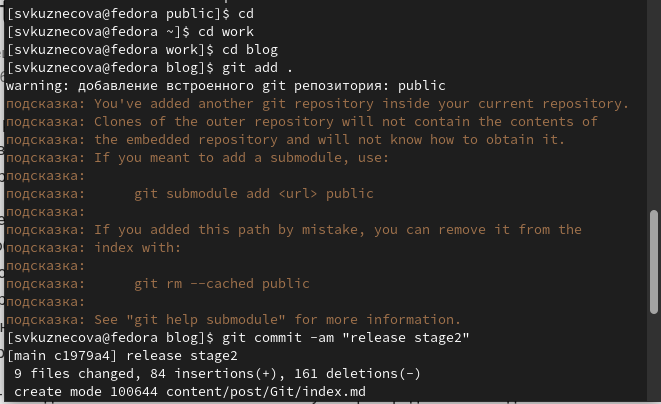

Выгрузка из подкаталога “blog”

## Просмотр изменений на сайте

[figure not shown]

Информация о себе на сайте

## Просмотр изменений на сайте

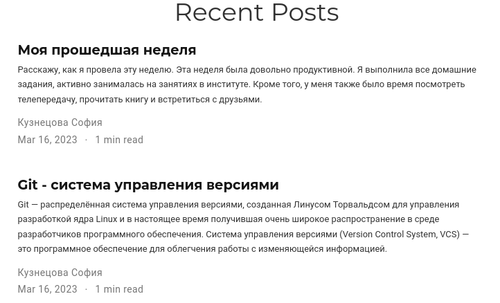

Новые посты на сайте

## Вывод

В ходе выполнения второго этапа индивидуального проекта мы научились добавлять к сайту информацию о себе, а также создавать новые посты.

Спасибо за внимание!